# clim_var_coldsum

Jens Joschinski

February 1, 2018

# General description

## Aim

The aim of this project is to correlate climate variability with variability in seasonal timing. Is the slope in seasonal responses a bet-hedging trait, i.e., is it adaptive to spread one’s timing in more variable conditions?

### Overview

This script processes climate station data to calculate winter variability. There are several ways to calculate variability, these are separate R scripts in subfolders of the folder “01climate_data/02processing”.

This scripts first connects with the NOAA server to get a list of available climate stations together with their latitudes and longitudes. This is the only time a connection to the server is required.

The script then open a pre-processed (with PERL) dataset, which includes daily average temeratures for all months, years and stations all over the world (~3million). The data is merged with the climate station data, cleaned, and saved as workspace to be used by other scripts.

### Specific description

The data was generated with R version 3.4.3. It uses the GHCN-daily dataset by NOAA:

```
## [1] "The current version of GHCN Daily is 3.22-upd-2018010805 (i.e, an update that started at 2018010805 [yyyymmddhh] UTC; yyyy=year; mm=month; dd=day; hh=hour),"
```

### Script

#### Read locations data

```r
url<-"ftp://ftp.ncdc.noaa.gov/pub/data/ghcn/daily/ghcnd-stations.txt"
#this dataset is fixed-width delimited, requiring a few additional steps
locations<-read.fwf(
  file=url
  ,sep="!",na.strings=c("NA","-999.9"), #sep = ! because ! does not exist in dataset - > dataset is fixed-width and should have no additional seps
  widths=c(11, 9, 10, 7,2,35)
)
#plot(locations[,2]~locations[,3],xlab = "longitude",ylab="latitude",pch=21, cex=0.1)
```

This dataset has only station ID, coordinates, altitude and name of the station, no actual data.  
The data was pre-processed with a PERL script, which now needs to be merged with the location data.

#### Read and merge climate station data

```r
#print(getwd())
#print(paste(getwd(),"/02processing/001data_conversion/converted.txt",sep=""))
converted<-fread(paste(getwd(),"/02processing/001data_conversion/converted.txt",sep=""), sep ="|", na.strings=c("NA","-9999"),verbose=T)
```

[output not shown]

```r
#this dataset has been made with the perl script conversion.pl in subfolder 01climatedata/02processing/001data_conversion
```

> this perl script takes the NOAA GHCN daily dataset (daily weather data for ~50 ys, around the whole world), and extracts daily average temperatures. it ignores all other data flags that are inside that dataset. The format of the old datasets is fixed-width delimited, the new one will be delimited by “|”. the new data is sorted in the following way: station1 | year 1 | month 1 | T(day1) | T(day2) |…| T(day31) station1 | year 1 | month 2… station1 | year 2 | month 1… station2| year 1 | month 1… missing data, and non-existent days (eg Feb 31) are called NA this script uses a local copy of the dataset from “ftp.ncdc.noaa.gov/pub/data/ghcn/daily/”; the .tar.gz file has to be extracted first (separate folder with 100,000 text files)

```r
newset<-merge.data.frame(converted,locations,by=1)
rm(converted)
#now newset contains daily temps of all stations + their coordinates and names

names(newset)<-c("ID","year","month",1:31,"lat","lon","alt","name","?")
#factors to numeric etc, further cleanup
newset<-droplevels(newset)
newset[,2]<-(as.integer(as.character(newset[,2])))
newset[,3]<-(as.integer(as.character(newset[,3])))
str(newset)
```

```
## 'data.frame':    3078856 obs. of  39 variables:
##  $ ID   : chr  "AE000041196" "AE000041196" "AE000041196" "AE000041196" ...
##  $ year : int  1944 1944 1944 1944 1944 1944 1944 1944 1944 1944 ...
##  $ month: int  3 4 5 6 7 8 9 10 11 12 ...
##  $ 1    : int  NA 224 257 300 331 337 327 312 272 210 ...
##  $ 2    : int  NA 227 264 306 327 345 345 302 266 224 ...
##  $ 3    : int  NA 216 253 300 331 342 344 293 269 214 ...
##  $ 4    : int  NA 210 268 304 323 341 341 295 263 217 ...
##  $ 5    : int  NA 218 262 306 353 335 341 301 252 219 ...
##  $ 6    : int  NA 228 292 303 346 335 329 309 277 218 ...
##  $ 7    : int  NA 246 287 302 367 356 318 292 265 192 ...
##  $ 8    : int  NA 276 276 293 344 347 319 280 260 209 ...
##  $ 9    : int  NA 288 284 321 337 338 331 284 261 192 ...
##  $ 10   : int  NA 261 293 333 335 344 319 278 256 204 ...
##  $ 11   : int  NA 240 283 332 327 349 318 281 263 195 ...
```

[output cut: 25 more lines]

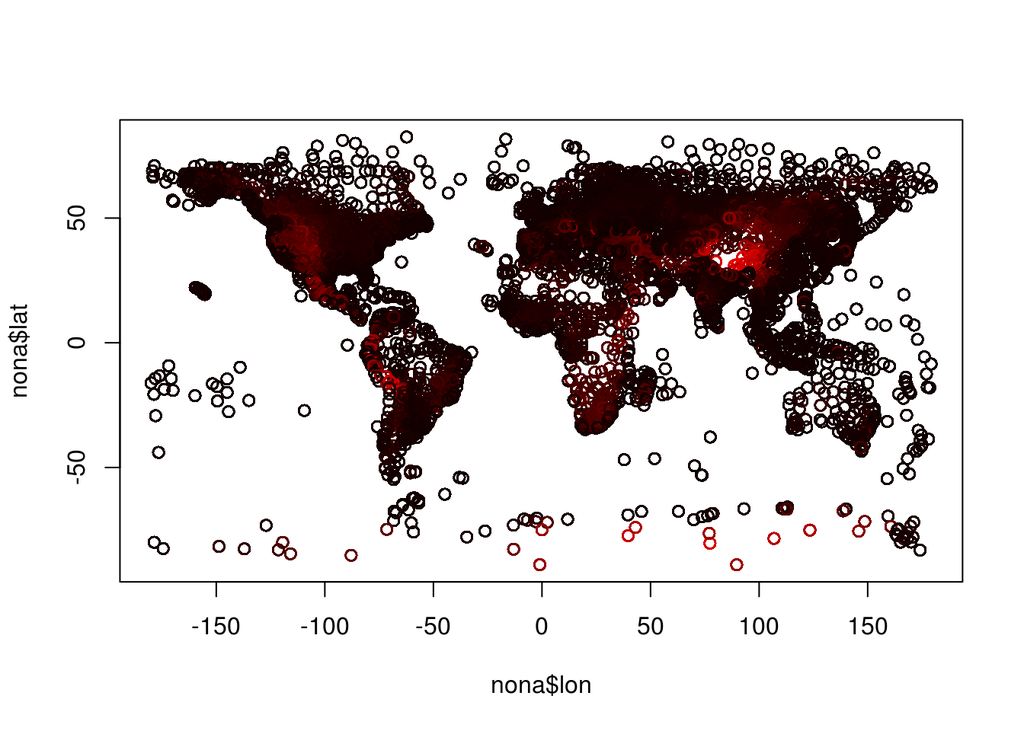

```r
newset$alt[newset$alt==-999.9]<-NA
nona<-newset
nona$alt<-nona$alt+350
nona<-nona[is.na(nona$alt)==F,]
plot(nona$lat~nona$lon,col=rgb(nona$alt,0,0,maxColorValue = max(nona$alt)))
```